# Visualization

07/09/2021

# DATA VISUALIZATION

```r
library(dplyr)
library(missForest)
```

```r
library(tidyr)
library(ggplot2)
library(ggthemes)
library(lubridate)
library(dplyr)
library(DT)
library(scales)
```

```r
colors = c("#CC1011", "#665555", "#05a399", "#cfcaca", "#f5e840", "#0683c9", "#e075b0")
```

```r
#loading the cleaned data set.
ds <- read.csv("cleaned_dataset.csv")
head(ds)
```

```
##   ID vendor_id pickup_loc drop_loc driver_tip mta_tax distance Pickup_date
## 1  0         1        170      233       1.83     0.5     0.70  2017-04-04
## 2  1         2        151      243       3.56     0.5     4.64  2017-03-04
## 3  2         2         68       90       1.50     0.5     1.29  2017-03-04
## 4  3         2        142      234       1.50     0.5     2.74  2017-04-04
## 5  4         2        238      238       0.00     0.5     0.45  2017-05-04
## 6  5         1        230       48       1.05     0.5     0.40  2017-03-04
##           Pickup_Time  Drop_date           Drop_Time num_passengers toll_amount
## 1 2021-11-23 17:59:00 2017-04-04 2021-11-23 18:05:00              1           0
## 2 2021-11-23 19:03:00 2017-03-04 2021-11-23 19:20:00              1           0
## 3 2021-11-23 15:06:00 2017-03-04 2021-11-23 15:12:00              2           0
## 4 2021-11-23 08:10:00 2017-04-04 2021-11-23 08:27:00              1           0
## 5 2021-11-23 14:02:00 2017-05-04 2021-11-23 14:05:00              6           0
## 6 2021-11-23 09:10:00 2017-03-04 2021-11-23 09:12:00              1           0
##   payment_method rate_code stored_flag extra_charges improvement_charge
## 1              1         1           N             1                0.3
## 2              1         1           N             1                0.3
## 3              1         1           N             0                0.3
## 4              1         1           N             0                0.3
## 5              2         1           N             0                0.3
## 6              1         1           N             0                0.3
##   total_amount Duration
## 1         9.13        6
## 2        21.36       17
## 3         8.80        6
## 4        14.80       17
## 5         4.80        3
## 6         5.35        2
```

## Pie Chart showing the percentages of vendor IDs

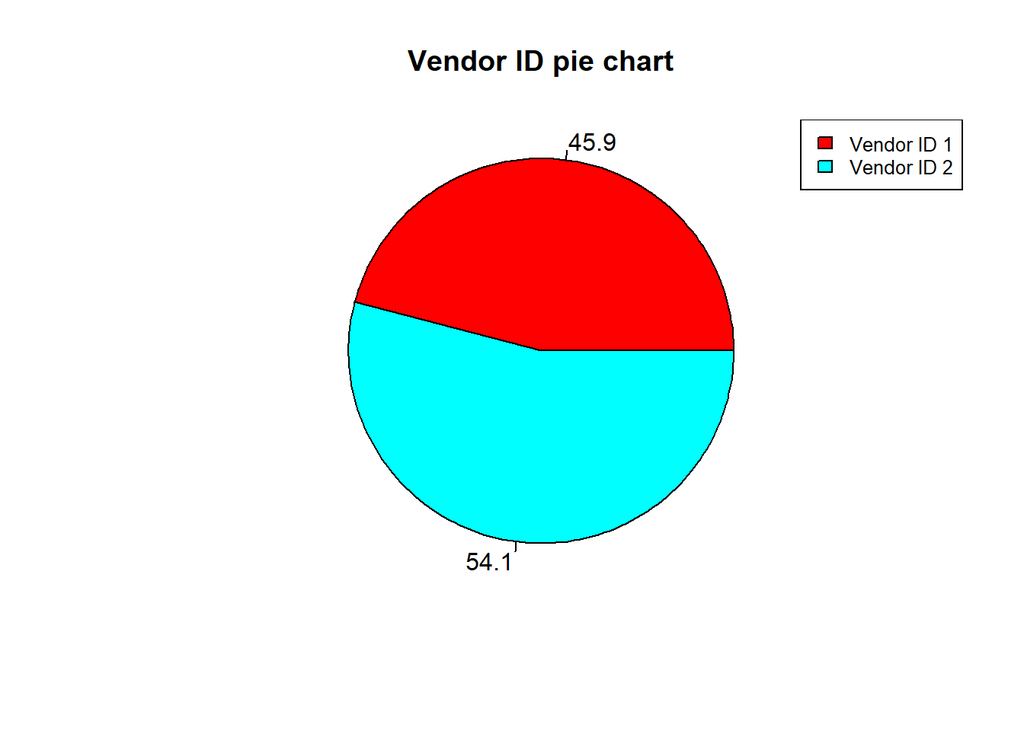

```r
x <- table(ds$vendor_id)
labels <- c("Vendor ID 1", "Vendor ID 2")
piepercent<- round(100*x/sum(x), 1)
pie(x, labels = piepercent, main = "Vendor ID pie chart", radius = 0.9, col = rainbow(length(x)))

legend("topright", c("Vendor ID 1","Vendor ID 2"), cex = 0.8,
   fill = rainbow(length(x)))
```

## Inference:

Vendors with ID 2 have greater occurrence than those with ID 1 in the given data set.

## Bar graph comparing number of passengers with number of Taxi Trips

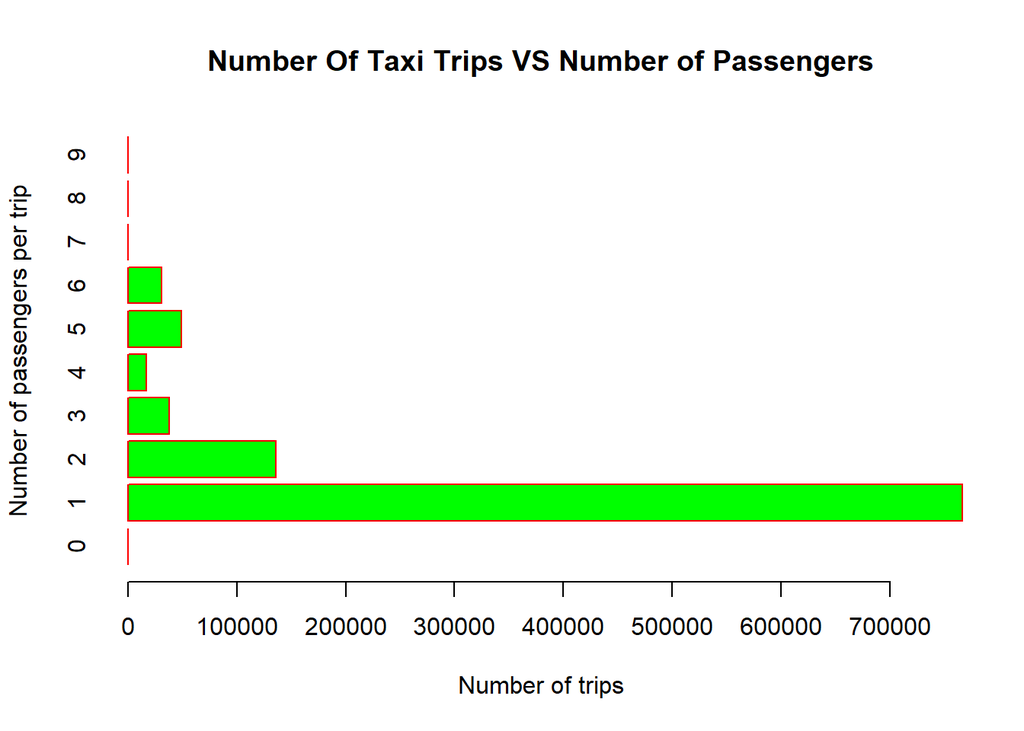

```r
options(scipen=10000)
barplot(table(ds$num_passengers),xlab = "Number of trips", ylab = "Number of passengers per trip", main = "Number Of Taxi Trips VS Number of Passengers", col="green", border="red", horiz=TRUE, sort="-")
```

## Inference:

From the above horizontal bar graph, we find that most of the trips are accompanied by a single passenger in the taxi.

## Bar graph for payment method

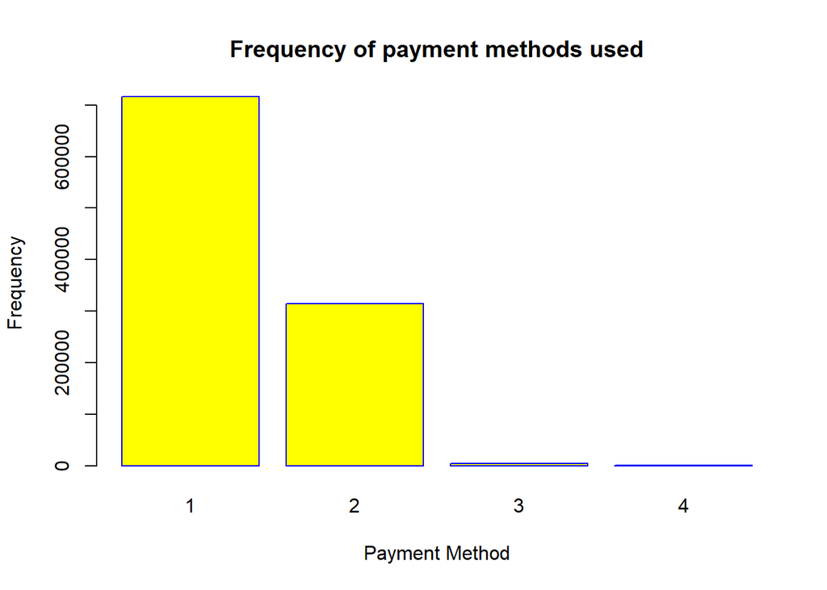

```r
barplot(table(ds$payment_method), xlab= "Payment Method", ylab="Frequency", main="Frequency of payment methods used", col="yellow", border="blue")
```

## Inference:

From the above bar graph, we find that payment method 1 is the most prevalent. Payment methods 3 and 4 have minimal occurence for the given data set.

## Scatter plot with a trend line to understand correlation between the distance and total amount of taxi fare.

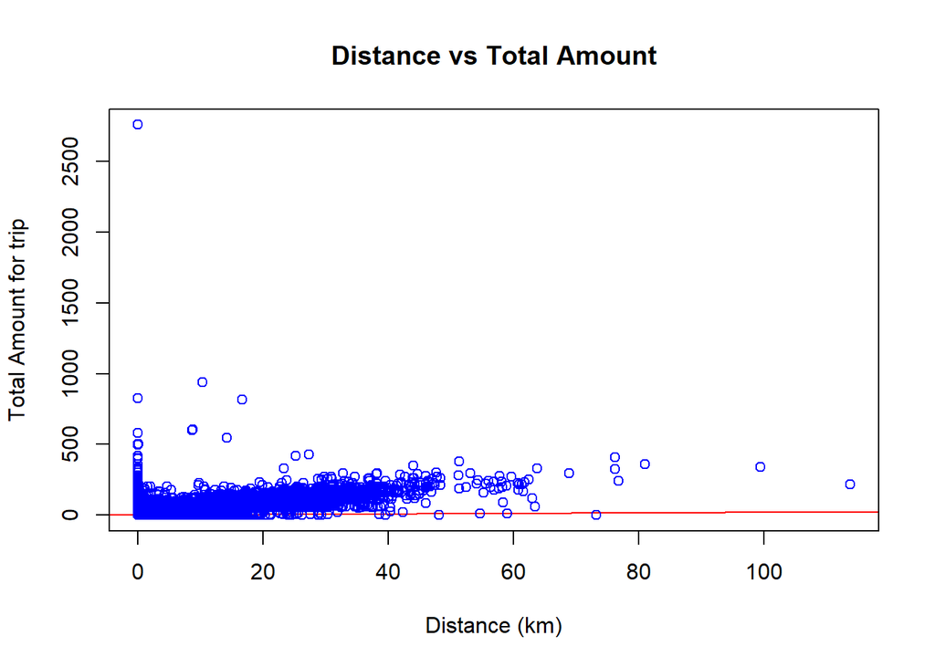

```r
plot(x = ds$distance,y = ds$total_amount,
   xlab = "Distance (km)",
   ylab = "Total Amount for trip",
   main = "Distance vs Total Amount",
   col = "blue",
   abline(lm(ds$distance ~ ds$total_amount), col="red")
)
```

## Histogram for pickup locations

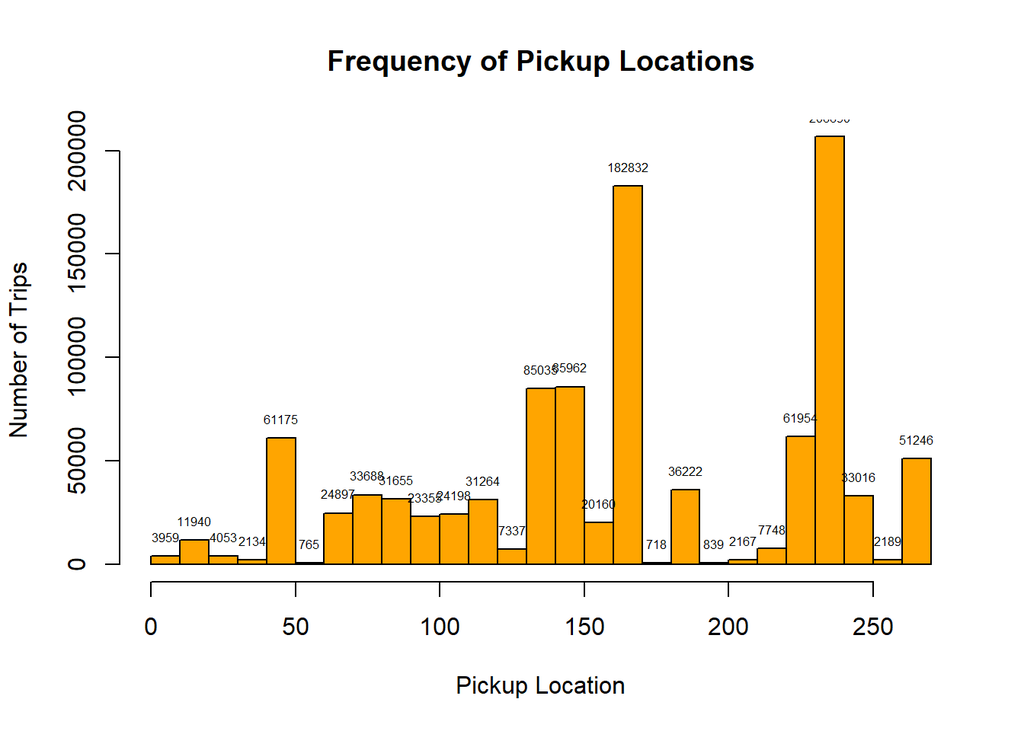

```r
h1<-hist(ds$pickup_loc,xlab="Pickup Location", ylab="Number of Trips", col="orange", main="Frequency of Pickup Locations")
text(h1$mids,h1$counts,labels=h1$counts, cex = 0.5, pos = 3)
```

## Inference:

The above histogram shows the distribution of pickup location with the number of trips. Some locations in the 150-200 and 200-250 range are highly picked by passengers.

## Histogram for drop location

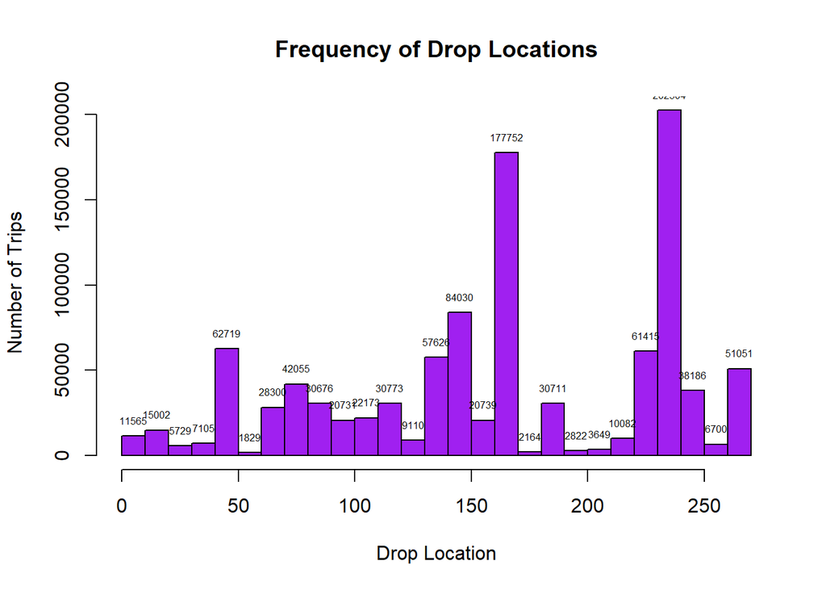

```r
h2<-hist(ds$drop_loc, xlab="Drop Location", ylab="Number of Trips", col="purple", main="Frequency of Drop Locations")
text(h2$mids,h2$counts,labels=h2$counts, cex = 0.5, pos = 3)
```

## Inference:

The above histogram shows the distribution of drop location with the number of trips. Some locations in the 150-200 and 200-250 range are the places where many trips end.